# **Assignment 12**

### **Topic: Propensity Score Pipeline**

This assignment applies **elastic net** as an additional method for estimating propensity scores using the same dataset from class (`nmes_data`). After propensity scores are estimated, individuals are matched and the association between smoking and respiratory outcomes is evaluated. The elastic net results are compared with logistic regression and random forest in terms of the number of individuals retained, covariate balance, and the estimated effect. The final model is then selected based on overall performance.

#### **nmes_data dataset**

The data come from a subset of the 1987 U.S. National Medical Expenditures Survey. The exposure is `eversmk` (a person has ever smoked or not), and the outcome is `lc5` (lung cancer, laryngeal cancer, or COPD). The covariates used to estimate the propensity score are *age, sex, race, education, seatbelt use, marital status, census region, and poverty status.*

### **Data preparation**

#### Load necessary packages

```r
library(MatchIt)
library(randomForest)
library(caret)
library(tidyverse)
library(glmnet)
```

#### Data cleaning

```r
# Import data
nmes_data <- read.delim("./nmes_data.txt")

# Keep only needed variables
keep.var <- c("LASTAGE", "MALE", "RACE3", "eversmk", "lc5", "beltuse",
              "educate", "marital", "SREGION", "POVSTALB")
nmes.data <- nmes_data[, keep.var]

str(nmes.data)
```

```
## 'data.frame':    13648 obs. of  10 variables:
##  $ LASTAGE : int  80 78 80 71 69 70 60 82 58 46 ...
##  $ MALE    : int  0 0 1 1 0 0 0 0 1 0 ...
##  $ RACE3   : int  3 3 3 3 3 3 3 3 3 3 ...
##  $ eversmk : chr  "0" "." "1" "1" ...
##  $ lc5     : int  0 0 0 0 0 0 0 0 0 0 ...
##  $ beltuse : chr  "3" "3" "1" "3" ...
##  $ educate : int  4 3 3 3 3 1 2 3 1 1 ...
##  $ marital : chr  "2" "2" "3" "1" ...
##  $ SREGION : int  1 1 1 1 1 1 1 1 1 1 ...
##  $ POVSTALB: chr  "1" "4" "3" "5" ...
```

*Note:* There are 13,648 observations and 10 variables.

```r
# Missing -- convert to "NA"
nmes.data[nmes.data == "."] <- NA

# Converting to factor
nmes.data$MALE <- as.factor(nmes.data$MALE)
nmes.data$educate <- as.factor(nmes.data$educate)
nmes.data$RACE3 <- as.factor(nmes.data$RACE3)
nmes.data$eversmk <- as.factor(nmes.data$eversmk)
nmes.data$SREGION <- as.factor(nmes.data$SREGION)
nmes.data$lc5 <- as.factor(nmes.data$lc5)
nmes.data$beltuse <- as.factor(nmes.data$beltuse)
nmes.data$marital <- as.factor(nmes.data$marital)
nmes.data$POVSTALB <- factor(nmes.data$POVSTALB, order = TRUE)

# Keep only complete cases
nmesdata <- na.omit(nmes.data)
```

#### Descriptive plot

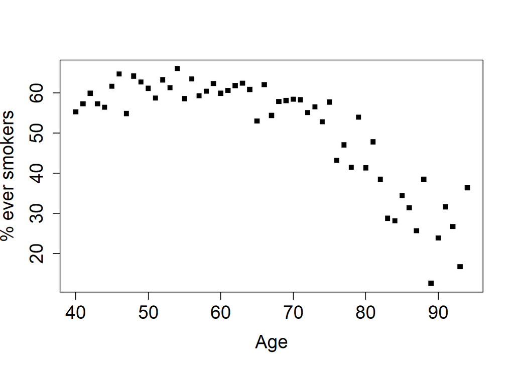

```r
temp <- table(nmesdata$eversmk, nmesdata$LASTAGE)
pct.eversmk <- 100 * (temp[2, ] / (temp[2, ] + temp[1, ]))

plot(40:94, pct.eversmk,
     xlab = "Age",
     ylab = "% ever smokers",
     pch = ".",
     cex = 7,
     cex.lab = 1.5,
     cex.axis = 1.5)
```

### **Propensity score estimation**

#### **Logistic regression propensity score**

The propensity score is estimated by using logistic regression with all covariates included in the model.

```r
ps.model.logit <- glm(
  eversmk ~ LASTAGE + MALE + educate + beltuse + POVSTALB + marital + RACE3 + SREGION,
  data = nmesdata,
  family = binomial(link = "logit")
)

summary(ps.model.logit)
```

```
##
## Call:
## glm(formula = eversmk ~ LASTAGE + MALE + educate + beltuse +
##     POVSTALB + marital + RACE3 + SREGION, family = binomial(link = "logit"),
##     data = nmesdata)
##
## Coefficients:
##              Estimate Std. Error z value Pr(>|z|)
## (Intercept)  0.020018   0.148777   0.135 0.892966
## LASTAGE     -0.013954   0.001776  -7.855 3.99e-15 ***
## MALE1        1.243409   0.043340  28.689  < 2e-16 ***
## educate2     0.488464   0.075457   6.473 9.58e-11 ***
## educate3     0.512041   0.063243   8.096 5.66e-16 ***
## educate4     0.288245   0.076641   3.761 0.000169 ***
## beltuse2    -0.072393   0.060908  -1.189 0.234608
## beltuse3    -0.234666   0.050383  -4.658 3.20e-06 ***
## POVSTALB.L  -0.084721   0.059652  -1.420 0.155529
## POVSTALB.Q   0.019649   0.053149   0.370 0.711610
## POVSTALB.C  -0.059725   0.063476  -0.941 0.346746
## POVSTALB^4   0.086412   0.059262   1.458 0.144801
## marital2    -0.043881   0.060417  -0.726 0.467657
## marital3     0.576635   0.075572   7.630 2.34e-14 ***
## marital4     0.337629   0.133302   2.533 0.011315 *
## marital5    -0.319467   0.093215  -3.427 0.000610 ***
## RACE32       0.334378   0.096055   3.481 0.000499 ***
## RACE33       0.585721   0.086275   6.789 1.13e-11 ***
## SREGION2    -0.230836   0.060626  -3.808 0.000140 ***
## SREGION3    -0.280376   0.056489  -4.963 6.93e-07 ***
## SREGION4    -0.139669   0.065546  -2.131 0.033101 *
## ---
## Signif. codes:  0 '***' 0.001 '**' 0.01 '*' 0.05 '.' 0.1 ' ' 1
##
## (Dispersion parameter for binomial family taken to be 1)
##
##     Null deviance: 15857  on 11586  degrees of freedom
## Residual deviance: 14565  on 11566  degrees of freedom
## AIC: 14607
##
## Number of Fisher Scoring iterations: 4
```

```r
prop.score <- predict(ps.model.logit, nmesdata, type = "response")
nmesdata$PS.LOGIT <- prop.score
```

#### **Random forest propensity score**

The propensity score is estimated by using random forest with all covariates included in the model.

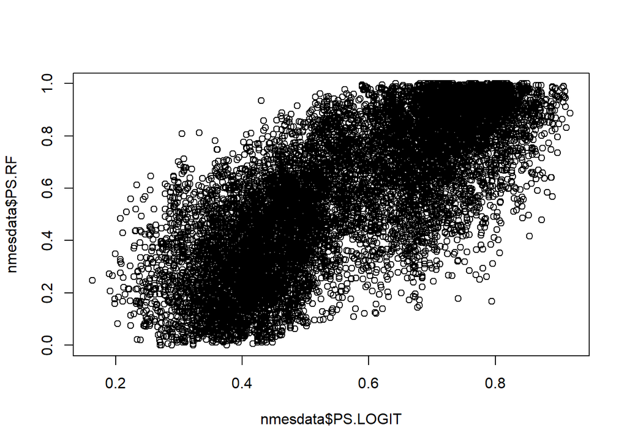

```r
set.seed(123)

feat.count <- c((ncol(nmesdata) - 4), (ncol(nmesdata) - 4) / 2, sqrt(ncol(nmesdata) - 4))
grid.rf <- expand.grid(mtry = feat.count)
tree.num <- seq(100, 500, by = 200)

results.trees <- list()

for (ntree in tree.num) {
  set.seed(123)
  rf.train <- train(
    eversmk ~ LASTAGE + MALE + educate + beltuse + POVSTALB + marital + RACE3 + SREGION,
    data = nmesdata,
    method = "rf",
    metric = "Accuracy",
    tuneGrid = grid.rf,
    importance = TRUE,
    ntree = ntree
  )
  index <- toString(ntree)
  results.trees[[index]] <- rf.train$results
}

output.trees <- bind_rows(results.trees, .id = "ntrees")
best.tune <- output.trees[which.max(output.trees[, "Accuracy"]), ]

set.seed(123)
ps.model.rf <- randomForest(
  eversmk ~ LASTAGE + MALE + educate + beltuse + POVSTALB + marital + RACE3 + SREGION,
  data = nmesdata,
  mtry = 3,
  ntree = 500
)

ps.rf <- ps.model.rf$votes
nmesdata$PS.RF <- ps.rf[, 2]

plot(nmesdata$PS.LOGIT, nmesdata$PS.RF)
```

#### **Elastic net propensity score**

Elastic net is used as an additional method to estimate the propensity score.

```r
set.seed(123)

nn1.en <- matchit(
  eversmk ~ LASTAGE + MALE + educate + beltuse + POVSTALB + marital + RACE3 + SREGION,
  data = nmesdata,
  distance = "elasticnet",
  distance.options = list(alpha = 0.5),
  method = "nearest",
  discard = "both",
  caliper = 0.2,
  ratio = 1
)

nmesdata$PS.EN <- nn1.en$distance
nn1.data.en <- match.data(nn1.en)
sum.en <- summary(nn1.en, standardize = TRUE)

summary(nn1.en, standardize = TRUE)
```

```
##
## Call:
## matchit(formula = eversmk ~ LASTAGE + MALE + educate + beltuse +
##     POVSTALB + marital + RACE3 + SREGION, data = nmesdata, method = "nearest",
##     distance = "elasticnet", distance.options = list(alpha = 0.5),
##     discard = "both", caliper = 0.2, ratio = 1)
##
## Summary of Balance for All Data:
##           Means Treated Means Control Std. Mean Diff. Var. Ratio eCDF Mean
## distance         0.6038        0.5177          0.6658     1.0851    0.1823
## LASTAGE         59.0891       61.6876         -0.2134     0.7858    0.0474
## MALE0            0.4459        0.7227         -0.5568          .    0.2768
## MALE1            0.5541        0.2773          0.5568          .    0.2768
## educate1         0.1316        0.1545         -0.0676          .    0.0229
## educate2         0.1507        0.1328          0.0500          .    0.0179
## educate3         0.5178        0.4704          0.0948          .    0.0474
## educate4         0.1999        0.2423         -0.1060          .    0.0424
## beltuse1         0.2599        0.2146          0.1033          .    0.0453
## beltuse2         0.2153        0.1915          0.0578          .    0.0237
## beltuse3         0.5248        0.5939         -0.1382          .    0.0690
## POVSTALB1        0.1018        0.1139         -0.0401          .    0.0121
## POVSTALB2        0.0457        0.0577         -0.0576          .    0.0120
## POVSTALB3        0.1397        0.1457         -0.0174          .    0.0060
## POVSTALB4        0.3167        0.3068          0.0214          .    0.0099
## POVSTALB5        0.3961        0.3759          0.0414          .    0.0202
## marital1         0.6846        0.6235          0.1315          .    0.0611
## marital2         0.1371        0.2280         -0.2641          .    0.0908
## marital3         0.1076        0.0685          0.1261          .    0.0391
## marital4         0.0276        0.0219          0.0347          .    0.0057
## marital5         0.0431        0.0581         -0.0739          .    0.0150
## RACE31           0.0526        0.0753         -0.1017          .    0.0227
## RACE32           0.1495        0.1666         -0.0482          .    0.0172
## RACE33           0.7980        0.7581          0.0993          .    0.0399
## SREGION1         0.2113        0.1760          0.0865          .    0.0353
## SREGION2         0.2473        0.2491         -0.0042          .    0.0018
## SREGION3         0.3524        0.3892         -0.0771          .    0.0368
## SREGION4         0.1891        0.1857          0.0085          .    0.0033
##           eCDF Max
## distance    0.2917
## LASTAGE     0.0954
```

[output cut: 78 more lines]

```
## marital5    0.0046          0.4618
## RACE31      0.0109          0.4880
## RACE32      0.0239          0.7170
## RACE33      0.0130          0.7807
## SREGION1    0.0504          0.7991
## SREGION2    0.0258          0.8487
## SREGION3    0.0204          0.8923
## SREGION4    0.0042          0.7649
##
## Sample Sizes:
##           Control Treated
## All          5023    6564
## Matched      4307    4307
## Unmatched     704    2257
## Discarded      12       0
```

### **Propensity score overlap**

Before matching, we examined the distribution of propensity scores in smokers and non-smokers to assess overlap. Matching works best when the two groups have similar ranges of propensity scores.

#### **Logistic regression overlap**

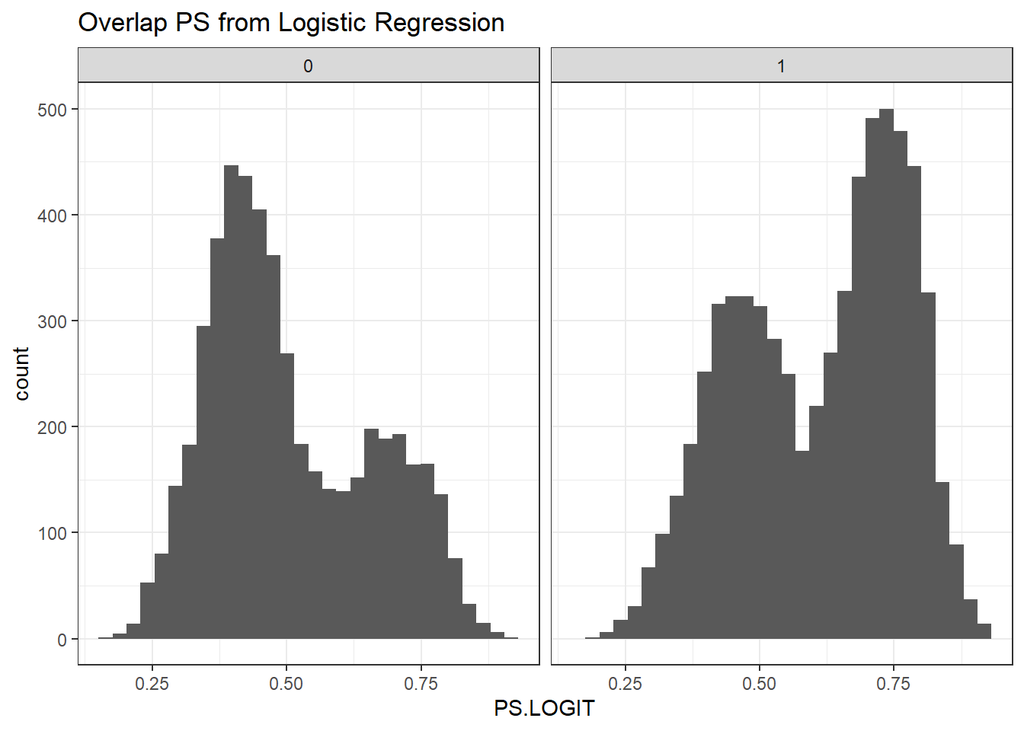

```r
ggplot(data = nmesdata, aes(x = PS.LOGIT)) +
  geom_histogram() +
  facet_grid(~eversmk) +
  theme_bw() +
  ggtitle("Overlap PS from Logistic Regression")
```

#### **Random forest overlap**

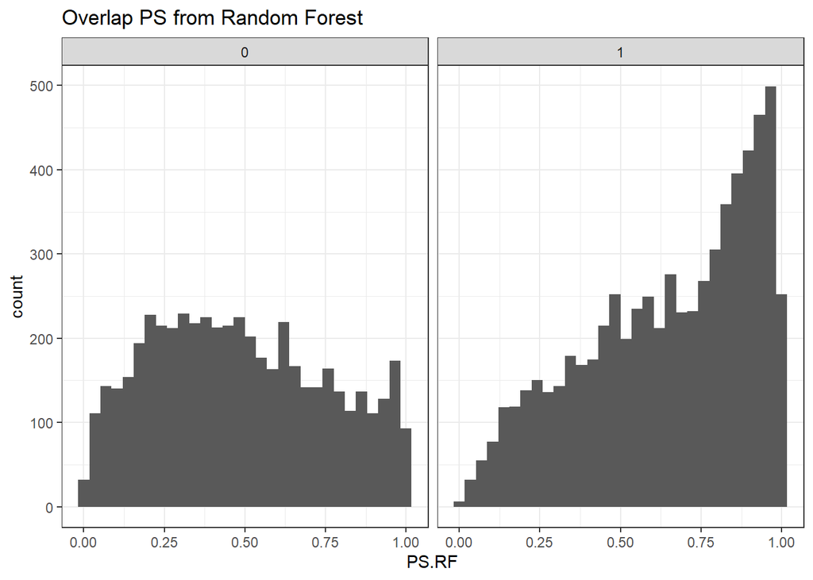

```r
ggplot(data = nmesdata, aes(x = PS.RF)) +
  geom_histogram() +
  facet_grid(~eversmk) +
  theme_bw() +
  ggtitle("Overlap PS from Random Forest")
```

#### **Elastic net overlap**

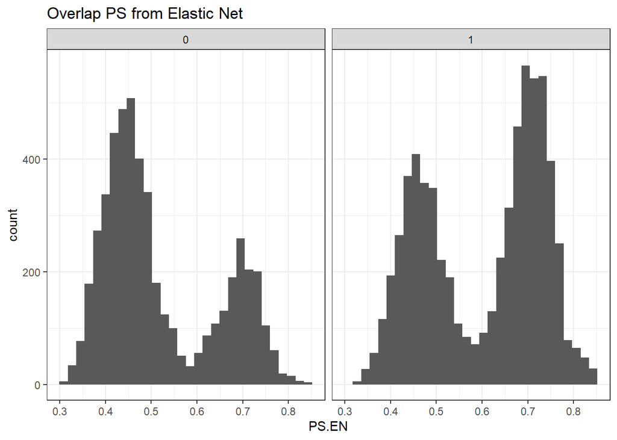

```r
ggplot(data = nmesdata, aes(x = PS.EN)) +
  geom_histogram() +
  facet_grid(~eversmk) +
  theme_bw() +
  ggtitle("Overlap PS from Elastic Net")
```

### **Matching and balance assessment**

We used 1:1 nearest-neighbor matching with a caliper of 0.2 and discarded observations outside the common support region. After matching, we assessed covariate balance using standardized mean differences, where smaller values indicate better balance.

#### **Logistic regression matching and balance**

```r
nn1 <- matchit(
  eversmk ~ LASTAGE + MALE + educate + beltuse + POVSTALB + marital + RACE3 + SREGION,
  data = nmesdata,
  distance = nmesdata$PS.LOGIT,
  method = "nearest",
  discard = "both",
  caliper = 0.2,
  ratio = 1
)

nn1.data <- match.data(nn1)
sum.logit <- summary(nn1, standardize = TRUE)

summary(nn1, standardize = TRUE)
```

```
##
## Call:
## matchit(formula = eversmk ~ LASTAGE + MALE + educate + beltuse +
##     POVSTALB + marital + RACE3 + SREGION, data = nmesdata, method = "nearest",
##     distance = nmesdata$PS.LOGIT, discard = "both", caliper = 0.2,
##     ratio = 1)
##
## Summary of Balance for All Data:
##           Means Treated Means Control Std. Mean Diff. Var. Ratio eCDF Mean
## distance         0.6132        0.5055          0.6945     1.0527    0.1891
## LASTAGE         59.0891       61.6876         -0.2134     0.7858    0.0474
## MALE0            0.4459        0.7227         -0.5568          .    0.2768
## MALE1            0.5541        0.2773          0.5568          .    0.2768
## educate1         0.1316        0.1545         -0.0676          .    0.0229
## educate2         0.1507        0.1328          0.0500          .    0.0179
## educate3         0.5178        0.4704          0.0948          .    0.0474
## educate4         0.1999        0.2423         -0.1060          .    0.0424
## beltuse1         0.2599        0.2146          0.1033          .    0.0453
## beltuse2         0.2153        0.1915          0.0578          .    0.0237
## beltuse3         0.5248        0.5939         -0.1382          .    0.0690
## POVSTALB1        0.1018        0.1139         -0.0401          .    0.0121
## POVSTALB2        0.0457        0.0577         -0.0576          .    0.0120
## POVSTALB3        0.1397        0.1457         -0.0174          .    0.0060
## POVSTALB4        0.3167        0.3068          0.0214          .    0.0099
## POVSTALB5        0.3961        0.3759          0.0414          .    0.0202
## marital1         0.6846        0.6235          0.1315          .    0.0611
## marital2         0.1371        0.2280         -0.2641          .    0.0908
## marital3         0.1076        0.0685          0.1261          .    0.0391
## marital4         0.0276        0.0219          0.0347          .    0.0057
## marital5         0.0431        0.0581         -0.0739          .    0.0150
## RACE31           0.0526        0.0753         -0.1017          .    0.0227
## RACE32           0.1495        0.1666         -0.0482          .    0.0172
## RACE33           0.7980        0.7581          0.0993          .    0.0399
## SREGION1         0.2113        0.1760          0.0865          .    0.0353
## SREGION2         0.2473        0.2491         -0.0042          .    0.0018
## SREGION3         0.3524        0.3892         -0.0771          .    0.0368
## SREGION4         0.1891        0.1857          0.0085          .    0.0033
##           eCDF Max
## distance    0.2997
## LASTAGE     0.0954
```

[output cut: 78 more lines]

```
## marital5    0.0023          0.4346
## RACE31      0.0023          0.4677
## RACE32      0.0044          0.7163
## RACE33      0.0021          0.7861
## SREGION1    0.0239          0.7827
## SREGION2    0.0064          0.8142
## SREGION3    0.0147          0.9182
## SREGION4    0.0028          0.7503
##
## Sample Sizes:
##           Control Treated
## All          5023    6564
## Matched      4350    4350
## Unmatched     667    2211
## Discarded       6       3
```

#### **Random forest matching and balance**

```r
nn1.rf <- matchit(
  eversmk ~ LASTAGE + MALE + educate + beltuse + POVSTALB + marital + RACE3 + SREGION,
  data = nmesdata,
  distance = nmesdata$PS.RF,
  method = "nearest",
  discard = "both",
  caliper = 0.2,
  ratio = 1
)

nn1.data.rf <- match.data(nn1.rf)
sum.rf <- summary(nn1.rf, standardize = TRUE)

summary(nn1.rf, standardize = TRUE)
```

```
##
## Call:
## matchit(formula = eversmk ~ LASTAGE + MALE + educate + beltuse +
##     POVSTALB + marital + RACE3 + SREGION, data = nmesdata, method = "nearest",
##     distance = nmesdata$PS.RF, discard = "both", caliper = 0.2,
##     ratio = 1)
##
## Summary of Balance for All Data:
##           Means Treated Means Control Std. Mean Diff. Var. Ratio eCDF Mean
## distance         0.6489        0.4843          0.6316     0.9478    0.1714
## LASTAGE         59.0891       61.6876         -0.2134     0.7858    0.0474
## MALE0            0.4459        0.7227         -0.5568          .    0.2768
## MALE1            0.5541        0.2773          0.5568          .    0.2768
## educate1         0.1316        0.1545         -0.0676          .    0.0229
## educate2         0.1507        0.1328          0.0500          .    0.0179
## educate3         0.5178        0.4704          0.0948          .    0.0474
## educate4         0.1999        0.2423         -0.1060          .    0.0424
## beltuse1         0.2599        0.2146          0.1033          .    0.0453
## beltuse2         0.2153        0.1915          0.0578          .    0.0237
## beltuse3         0.5248        0.5939         -0.1382          .    0.0690
## POVSTALB1        0.1018        0.1139         -0.0401          .    0.0121
## POVSTALB2        0.0457        0.0577         -0.0576          .    0.0120
## POVSTALB3        0.1397        0.1457         -0.0174          .    0.0060
## POVSTALB4        0.3167        0.3068          0.0214          .    0.0099
## POVSTALB5        0.3961        0.3759          0.0414          .    0.0202
## marital1         0.6846        0.6235          0.1315          .    0.0611
## marital2         0.1371        0.2280         -0.2641          .    0.0908
## marital3         0.1076        0.0685          0.1261          .    0.0391
## marital4         0.0276        0.0219          0.0347          .    0.0057
## marital5         0.0431        0.0581         -0.0739          .    0.0150
## RACE31           0.0526        0.0753         -0.1017          .    0.0227
## RACE32           0.1495        0.1666         -0.0482          .    0.0172
## RACE33           0.7980        0.7581          0.0993          .    0.0399
## SREGION1         0.2113        0.1760          0.0865          .    0.0353
## SREGION2         0.2473        0.2491         -0.0042          .    0.0018
## SREGION3         0.3524        0.3892         -0.0771          .    0.0368
## SREGION4         0.1891        0.1857          0.0085          .    0.0033
##           eCDF Max
## distance    0.2655
## LASTAGE     0.0954
```

[output cut: 78 more lines]

```
## marital5    0.0073          0.5255
## RACE31      0.0128          0.5526
## RACE32      0.0057          0.7612
## RACE33      0.0186          0.8972
## SREGION1    0.0214          0.7606
## SREGION2    0.0038          0.8396
## SREGION3    0.0265          0.9678
## SREGION4    0.0013          0.7845
##
## Sample Sizes:
##           Control Treated
## All          5023    6564
## Matched      4525    4525
## Unmatched     493    2039
## Discarded       5       0
```

#### **Elastic net balance**

```r
mean(abs(sum.en$sum.matched[, 3][-1]))
```

```
## [1] 0.05916788
```

#### **Balance summary across models**

```r
mean(abs(sum.logit$sum.all[, 3][-1]))
```

```
## [1] 0.1177137
```

```r
mean(abs(sum.logit$sum.matched[, 3][-1]))
```

```
## [1] 0.03219356
```

```r
mean(abs(sum.rf$sum.matched[, 3][-1]))
```

```
## [1] 0.06000446
```

```r
mean(abs(sum.en$sum.matched[, 3][-1]))
```

```
## [1] 0.05916788
```

### **Effect estimates**

After matching, we fit logistic regression models for the outcome using smoking status as the predictor, and report odds ratios and confidence intervals for each matched sample.

#### **Logistic regression effect estimate**

```r
outcome.model.1 <- glm(lc5 ~ eversmk, data = nn1.data, family = binomial(link = "logit"))
exp(outcome.model.1$coefficients)
```

```
## (Intercept)    eversmk1
## 0.004386978 6.079313814
```

```r
exp(confint(outcome.model.1))
```

```
##                   2.5 %       97.5 %
## (Intercept) 0.002695883  0.006672937
## eversmk1    3.827702999 10.211477865
```

#### **Random forest effect estimate**

```r
outcome.model.2 <- glm(lc5 ~ eversmk, data = nn1.data.rf, family = binomial(link = "logit"))
exp(outcome.model.2$coefficients)
```

```
## (Intercept)    eversmk1
## 0.004662522 5.792706915
```

```r
exp(confint(outcome.model.2))
```

```
##                   2.5 %      97.5 %
## (Intercept) 0.002939295 0.006958231
## eversmk1    3.719039182 9.486140714
```

#### **Elastic net effect estimate**

```r
outcome.model.3 <- glm(lc5 ~ eversmk, data = nn1.data.en,
                       family = binomial(link = "logit"))

exp(outcome.model.3$coefficients)
```

```
## (Intercept)    eversmk1
## 0.004665267 5.565543116
```

```r
exp(confint(outcome.model.3))
```

```
##                   2.5 %      97.5 %
## (Intercept) 0.002905112 0.007026812
## eversmk1    3.530326697 9.243991498
```

### **Model comparison**

Finally, the three propensity score models based on the number of individuals retained after matching, the average absolute standardized mean difference after matching, and the estimated odds ratio for smoking.

```r
n.logit <- nrow(nn1.data)
n.rf <- nrow(nn1.data.rf)
n.en <- nrow(nn1.data.en)

smd.unmatched <- mean(abs(sum.logit$sum.all[, 3][-1]))
smd.logit <- mean(abs(sum.logit$sum.matched[, 3][-1]))
smd.rf <- mean(abs(sum.rf$sum.matched[, 3][-1]))
smd.en <- mean(abs(sum.en$sum.matched[, 3][-1]))

or.logit <- exp(coef(outcome.model.1)["eversmk1"])
or.rf <- exp(coef(outcome.model.2)["eversmk1"])
or.en <- exp(coef(outcome.model.3)["eversmk1"])

ci.logit <- exp(confint(outcome.model.1))["eversmk1", ]
ci.rf <- exp(confint(outcome.model.2))["eversmk1", ]
ci.en <- exp(confint(outcome.model.3))["eversmk1", ]

comparison <- data.frame(
  Model = c("Logistic Regression", "Random Forest", "Elastic Net"),
  N_included = c(n.logit, n.rf, n.en),
  Unmatched_Avg_abs_SMD = round(c(smd.unmatched, smd.unmatched, smd.unmatched), 4),
  Matched_Avg_abs_SMD = round(c(smd.logit, smd.rf, smd.en), 4),
  OR = round(c(or.logit, or.rf, or.en), 3),
  CI_Lower = round(c(ci.logit[1], ci.rf[1], ci.en[1]), 3),
  CI_Upper = round(c(ci.logit[2], ci.rf[2], ci.en[2]), 3)
)

knitr::kable(comparison, caption = "Comparison of propensity score models")
```

Comparison of propensity score models

| Model | N_included | Unmatched_Avg_abs_SMD | Matched_Avg_abs_SMD | OR | CI_Lower | CI_Upper |
| --- | --- | --- | --- | --- | --- | --- |
| Logistic Regression | 8700 | 0.1177 | 0.0322 | 6.079 | 3.828 | 10.211 |
| Random Forest | 9050 | 0.1177 | 0.0600 | 5.793 | 3.719 | 9.486 |
| Elastic Net | 8614 | 0.1177 | 0.0592 | 5.566 | 3.530 | 9.244 |

**Conclusion**

The three propensity score models gave slightly different results after matching.

- **Number retained:** Logistic regression retained 8,700 individuals, random forest retained 9,050, and elastic net retained 8,614.
- **Average absolute standardized mean difference (SMD) after matching:** 0.0322 (logistic regression), 0.0600 (random forest), and 0.0592 (elastic net).
- **Odds ratio for ever smoking:** 6.079 (logistic regression), 5.793 (random forest), and 5.566 (elastic net).

Based on these results, **logistic regression** was selected as the final model because it achieved the lowest average absolute SMD after matching, indicating the best covariate balance among the three approaches. Although random forest retained the largest number of individuals, its post-matching balance was poorer than that of logistic regression. In addition, the estimated odds ratios were fairly similar across models, suggesting that logistic regression provided a reasonable effect estimate while also achieving the best overall balance with a sufficient matched sample size.

#### **AI tools**

Claude.ai was used in this assignment to assist with debugging R code syntax errors and editing text for clarity and conciseness.